# Chapter 11:

Marjorie Blanco

Chapter 11 Page 402: #11.9 part (a)

1. You may use R to solve this part (NO built-in function). To get full credit, make sure you include the following steps, with code and output:
1. the sample correlation matrix

```r
sons <- read_table("Software-Files/T3_8_SONS.DAT", col_names = c("y1", "y2", "x1", "x2"))
sons <- as.matrix(sons)
kable(sons) %>%
  kable_styling(bootstrap_options = "striped")
```

| y1 | y2 | x1 | x2 |
| --- | --- | --- | --- |
| 191 | 155 | 179 | 145 |
| 195 | 149 | 201 | 152 |
| 181 | 148 | 185 | 149 |
| 183 | 153 | 188 | 149 |
| 176 | 144 | 171 | 142 |
| 208 | 157 | 192 | 152 |
| 189 | 150 | 190 | 149 |
| 197 | 159 | 189 | 152 |
| 188 | 152 | 197 | 159 |
| 192 | 150 | 187 | 151 |
| 179 | 158 | 186 | 148 |
| 183 | 147 | 174 | 147 |
| 174 | 150 | 185 | 152 |
| 190 | 159 | 195 | 157 |
| 188 | 151 | 187 | 158 |
| 163 | 137 | 161 | 130 |
| 195 | 155 | 183 | 158 |
| 186 | 153 | 173 | 148 |
| 181 | 145 | 182 | 146 |
| 175 | 140 | 165 | 137 |
| 192 | 154 | 185 | 152 |
| 174 | 143 | 178 | 147 |
| 176 | 139 | 176 | 143 |
| 197 | 167 | 200 | 158 |
| 190 | 163 | 187 | 150 |

```r
sons.std <-sweep(sons, 2, sqrt(apply(sons,2,var)), FUN="/")
first.son.meas <-sons.std[,1:2]
second.son.meas <-sons.std[,3:4]
```

first.son.meas =

```r
kable(first.son.meas) %>%
  kable_styling(bootstrap_options = "striped")
```

| y1 | y2 |
| --- | --- |
| 19.56600 | 21.02287 |
| 19.97576 | 20.20908 |
| 18.54160 | 20.07345 |
| 18.74648 | 20.75161 |
| 18.02941 | 19.53092 |
| 21.30748 | 21.29413 |
| 19.36112 | 20.34471 |
| 20.18064 | 21.56539 |
| 19.25868 | 20.61597 |
| 19.66844 | 20.34471 |
| 18.33673 | 21.42976 |
| 18.74648 | 19.93782 |
| 17.82453 | 20.34471 |
| 19.46356 | 21.56539 |
| 19.25868 | 20.48034 |
| 16.69769 | 18.58150 |
| 19.97576 | 21.02287 |
| 19.05380 | 20.75161 |
| 18.54160 | 19.66655 |
| 17.92697 | 18.98840 |
| 19.66844 | 20.88724 |
| 17.82453 | 19.39529 |
| 18.02941 | 18.85277 |
| 20.18064 | 22.65045 |
| 19.46356 | 22.10792 |

second.son.meas =

```r
kable(second.son.meas) %>%
  kable_styling(bootstrap_options = "striped")
```

| x1 | x2 |
| --- | --- |
| 17.82824 | 21.60972 |
| 20.01942 | 22.65295 |
| 18.42583 | 22.20585 |
| 18.72463 | 22.20585 |
| 17.03144 | 21.16262 |
| 19.12303 | 22.65295 |
| 18.92383 | 22.20585 |
| 18.82423 | 22.65295 |
| 19.62102 | 23.69618 |
| 18.62503 | 22.50392 |
| 18.52543 | 22.05682 |
| 17.33024 | 21.90779 |
| 18.42583 | 22.65295 |
| 19.42182 | 23.39811 |
| 18.62503 | 23.54715 |
| 16.03545 | 19.37423 |
| 18.22663 | 23.54715 |
| 17.23064 | 22.05682 |
| 18.12703 | 21.75875 |
| 16.43385 | 20.41746 |
| 18.42583 | 22.65295 |
| 17.72864 | 21.90779 |
| 17.52944 | 21.31166 |
| 19.91982 | 23.54715 |
| 18.62503 | 22.35488 |

```r
R11 <-cor(first.son.meas)
R11
```

```
##           y1        y2
## y1 1.0000000 0.7345555
## y2 0.7345555 1.0000000
```

```r
R22 <-cor(second.son.meas)
R22
```

```
##           x1        x2
## x1 1.0000000 0.8392519
## x2 0.8392519 1.0000000
```

```r
R12 <-c(cor(first.son.meas[,1], second.son.meas[,1]),
        cor(first.son.meas[,1], second.son.meas[,2]),
        cor(first.son.meas[,2], second.son.meas[,1]),
        cor(first.son.meas[,2], second.son.meas[,2]))
```

R12 =

```r
R12 <-matrix(R12, ncol=ncol(R22), byrow=T) # R12 has q2 columns, same as number of petal measurements
R12
```

```
##           [,1]      [,2]
## [1,] 0.7107518 0.7039807
## [2,] 0.6931573 0.7085504
```

```r
R21 <-t(R12)  # R21=transpose of R12
```

```r
S <- cbind(rbind(R22, R12), rbind(R21, R11))
```

S =

```
##           x1        x2        y1        y2
## x1 1.0000000 0.8392519 0.7107518 0.6931573
## x2 0.8392519 1.0000000 0.7039807 0.7085504
##    0.7107518 0.7039807 1.0000000 0.7345555
##    0.6931573 0.7085504 0.7345555 1.0000000
```

```r
cor(sons)
```

```
##           y1        y2        x1        x2
## y1 1.0000000 0.7345555 0.7107518 0.7039807
## y2 0.7345555 1.0000000 0.6931573 0.7085504
## x1 0.7107518 0.6931573 1.0000000 0.8392519
## x2 0.7039807 0.7085504 0.8392519 1.0000000
```

2. the characteristic equation

```r
# Finding the E1 and E2 matrices:
E1 <-solve(R11) %*% R12 %*% solve(R22) %*% R21
E2 <-solve(R22) %*% R21 %*% solve(R11) %*% R12
eigen(E1)
```

```
## eigen() decomposition
## $values
## [1] 0.621744734 0.002887956
##
## $vectors
##           [,1]       [,2]
## [1,] 0.7269968 -0.7040109
## [2,] 0.6866408  0.7101892
```

```r
eigen(E2)
```

```
## eigen() decomposition
## $values
## [1] 0.621744734 0.002887956
##
## $vectors
##            [,1]       [,2]
## [1,] -0.6837994 -0.7091095
## [2,] -0.7296700  0.7050984
```

u1 = 0.7269968 * First Son Head Length + 0.6866408 * First Son Head Breadth

v1 = -0.6837994 * Second Son Head Length + -0.72967 * Second Son Head Breadth

u2 = -0.7040109 * First Son Head Length + 0.7101892 * First Son Head Breadth

v2 = -0.7091095 * Second Son Head Length + 0.7050984 * Second Son Head Breadth

3. eigenvalues

```r
eigen(E1)$values
```

```
## [1] 0.621744734 0.002887956
```

```r
eigen(E2)$values
```

```
## [1] 0.621744734 0.002887956
```

1. Find the canonical correlations between ($y_1$, $y_2$) and ($x_1$, $x_2$).

```r
canon.corr <-sqrt(eigen(E1)$values)
canon.corr
```

```
## [1] 0.7885079 0.0537397
```

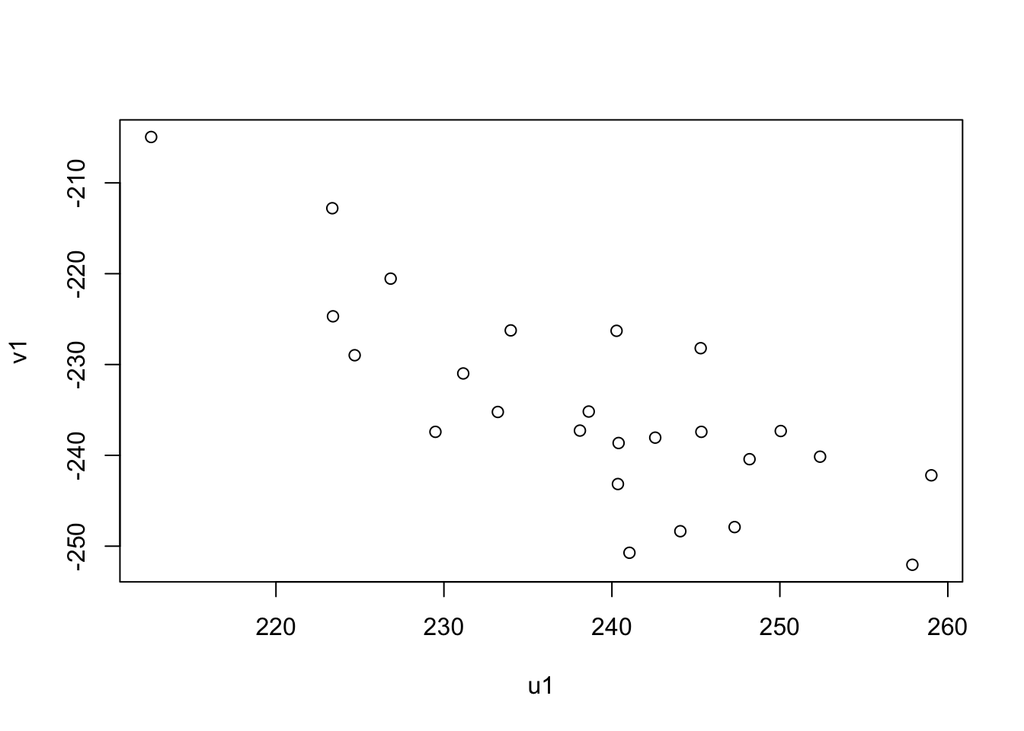

```r
# Plotting the first set of canonical variables:
u1 <-as.matrix(sons[,1:2]) %*% as.matrix(eigen(E1)$vectors[,1])
v1 <-as.matrix(sons[,3:4]) %*% as.matrix(eigen(E2)$vectors[,1])
plot(u1,v1)
```

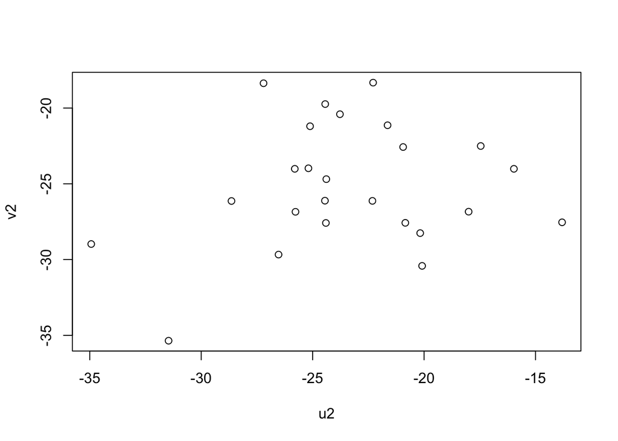

```r
# Plotting the second set of canonical variables:
u2 <-as.matrix(sons[,1:2]) %*% as.matrix(eigen(E1)$vectors[,2])
v2 <-as.matrix(sons[,3:4]) %*% as.matrix(eigen(E2)$vectors[,2])
plot(u2,v2)
```

$r_1$ = 0.7885079

$r_2$ = 0.0537397

The first canonical variate captures the most explained variance, canonical r = 0.7885079.

```r
cca1 <- cancor(first.son.meas, second.son.meas)
# The canonical correlations are the same as the ones we found,
# The canonical variates are a little different because the cancor
# function works with the centered data rather than the original data.
cca1
```

```
## $cor
## [1] 0.7885079 0.0537397
##
## $xcoef
##         [,1]       [,2]
## y1 0.1127152 -0.2789099
## y2 0.1064583  0.2813576
##
## $ycoef
##         [,1]       [,2]
## x1 0.1029701 -0.3610078
## x2 0.1098775  0.3589657
##
## $xcenter
##       y1       y2
## 19.02512 20.49662
##
## $ycenter
##       x1       x2
## 18.31030 22.24162
```

```r
cc(first.son.meas, second.son.meas)
```

```
## $cor
## [1] 0.7885079 0.0537397
##
## $names
## $names$Xnames
## [1] "y1" "y2"
##
## $names$Ynames
## [1] "x1" "x2"
##
## $names$ind.names
## NULL
##
##
## $xcoef
##          [,1]      [,2]
## y1 -0.5521896 -1.366374
## y2 -0.5215372  1.378365
##
## $ycoef
##          [,1]      [,2]
## x1 -0.5044484 -1.768570
## x2 -0.5382877  1.758566
##
## $scores
## $scores$xscores
##              [,1]        [,2]
##  [1,] -0.57312842 -0.01368291
##  [2,] -0.37497221 -1.69526490
##  [3,]  0.48769136  0.07738080
##  [4,]  0.02087481  0.73218662
##  [5,]  1.05346966  0.02943785
##  [6,] -1.67622740 -2.01929228
##  [7,] -0.10631187 -0.66848874
##  [8,] -1.19547291 -0.10571105
##  [9,] -0.19121934 -0.15461844
## [10,] -0.27601046 -1.08840202
## [11,] -0.10654457  2.22681901
## [12,]  0.44529580 -0.38951099
## [13,]  0.74218106  1.43107765
```

[output cut: 45 more lines]

```
##
## $scores$corr.Y.xscores
##          [,1]        [,2]
## x1 -0.7539771 -0.01572908
## x2 -0.7582663  0.01474027
##
## $scores$corr.X.yscores
##          [,1]        [,2]
## y1 -0.7374817 -0.01901786
## y2 -0.7310660  0.02013559
##
## $scores$corr.Y.yscores
##          [,1]       [,2]
## x1 -0.9562074 -0.2926900
## x2 -0.9616470  0.2742901
```

```r
sons <- read_table("Software-Files/T3_8_SONS.DAT", col_names = c("First.Son.Head.Length", "First.Son.Head.Breadth", "Second.Son.Head.Length", "Second.Son.Head.Breadth"))
sons <- as.matrix(sons)
```

Display the canonical correlations

```r
first.son <- sons[,1:2]
second.son <- sons[,3:4]
cc1 <- cc(first.son, second.son)

# display the canonical correlations
cc1$cor
```

```
## [1] 0.7885079 0.0537397
```

```r
xcoef <- cc1[1:2]

ycoef <- cc1[3:4]

cc1[3:4]
```

```
## $xcoef
##                               [,1]       [,2]
## First.Son.Head.Length  -0.05656620 -0.1399711
## First.Son.Head.Breadth -0.07073683  0.1869496
##
## $ycoef
##                               [,1]       [,2]
## Second.Son.Head.Length  -0.0502426 -0.1761479
## Second.Son.Head.Breadth -0.0802224  0.2620836
```

The raw canonical coefficients are interpreted similar to interpreting regression coefficients.

For Second.Son.Head.Length, a one unit increase in Second.Son.Head.Length leads to a 0.0502426 decrease in the first canonical variate, holding all other variables constant.

For Second.Son.Head.Length, a one unit increase in Second.Son.Head.Length leads to a 0.1761479 decrease in the second canonical variate, holding all other variables constant.

For Second.Son.Head.Breadth, a one unit increase in Second.Son.Head.Breadth leads to a 0.2620836 increase in the second canonical variate, holding all other variables constant.

Compute canonical loadings

```r
cc2 <- comput(first.son, second.son, cc1)
```

Display canonical loadings

```r
cc2[3:6]
```

```
## $corr.X.xscores
##                              [,1]       [,2]
## First.Son.Head.Length  -0.9352877 -0.3538884
## First.Son.Head.Breadth -0.9271512  0.3746875
##
## $corr.Y.xscores
##                               [,1]        [,2]
## Second.Son.Head.Length  -0.7539771 -0.01572908
## Second.Son.Head.Breadth -0.7582663  0.01474027
##
## $corr.X.yscores
##                              [,1]        [,2]
## First.Son.Head.Length  -0.7374817 -0.01901786
## First.Son.Head.Breadth -0.7310660  0.02013559
##
## $corr.Y.yscores
##                               [,1]       [,2]
## Second.Son.Head.Length  -0.9562074 -0.2926900
## Second.Son.Head.Breadth -0.9616470  0.2742901
```

```r
# tests of canonical dimensions
ev <- (1 - cc1$cor^2)

n <- dim(first.son)[1]
p <-dim(first.son)[2]
q <- dim(second.son)[2]
k <- min(p, q)
m <- n - 3/2 - (p + q)/2

w <- rev(cumprod(rev(ev)))

# initialize
d1 <- d2 <- f <- vector("numeric", k)

for (i in 1:k) {
    s <- sqrt((p^2 * q^2 - 4)/(p^2 + q^2 - 5))
    si <- 1/s
    d1[i] <- p * q
    d2[i] <- m * s - p * q/2 + 1
    r <- (1 - w[i]^si)/w[i]^si
    f[i] <- r * d2[i]/d1[i]
    p <- p - 1
    q <- q - 1
}

pv <- pf(f, d1, d2, lower.tail = FALSE)
(dmat <- cbind(WilksL = w, F = f, df1 = d1, df2 = d2, p = pv))
```

```
##         WilksL          F df1 df2            p
## [1,] 0.3771629 6.59719349   4  42 0.0003256458
## [2,] 0.9971120 0.06371905   1  22 0.8030550074
```

Standardized first.son canonical coefficients diagonal matrix of first.son sd’s

```r
s1 <- diag(sqrt(diag(cov(first.son))))
s1 %*% cc1$xcoef
```

```
##            [,1]      [,2]
## [1,] -0.5521896 -1.366374
## [2,] -0.5215372  1.378365
```

Standardized second.son canonical coefficients diagonal matrix of second.son sd’s

```r
s2 <- diag(sqrt(diag(cov(second.son))))
s2 %*% cc1$ycoef
```

```
##            [,1]      [,2]
## [1,] -0.5044484 -1.768570
## [2,] -0.5382877  1.758566
```

```r
matcor(first.son, second.son)
```

```
## $Xcor
##                        First.Son.Head.Length First.Son.Head.Breadth
## First.Son.Head.Length              1.0000000              0.7345555
## First.Son.Head.Breadth             0.7345555              1.0000000
##
## $Ycor
##                         Second.Son.Head.Length Second.Son.Head.Breadth
## Second.Son.Head.Length               1.0000000               0.8392519
## Second.Son.Head.Breadth              0.8392519               1.0000000
##
## $XYcor
##                         First.Son.Head.Length First.Son.Head.Breadth
## First.Son.Head.Length               1.0000000              0.7345555
## First.Son.Head.Breadth              0.7345555              1.0000000
## Second.Son.Head.Length              0.7107518              0.6931573
## Second.Son.Head.Breadth             0.7039807              0.7085504
##                         Second.Son.Head.Length Second.Son.Head.Breadth
## First.Son.Head.Length                0.7107518               0.7039807
## First.Son.Head.Breadth               0.6931573               0.7085504
## Second.Son.Head.Length               1.0000000               0.8392519
## Second.Son.Head.Breadth              0.8392519               1.0000000
```

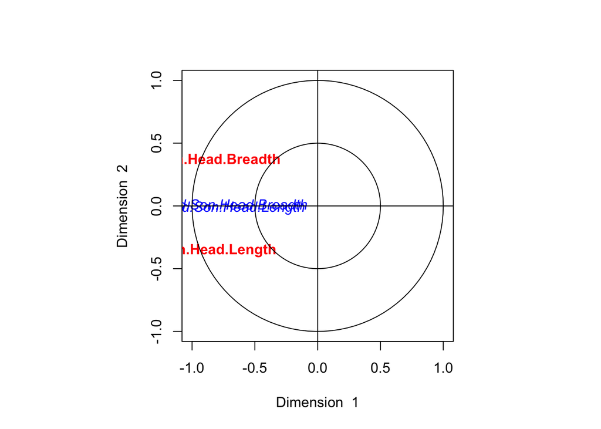

```r
plt.cc(cc1, type="v", var.label = TRUE)
```

```r
options(scipen=999) # Permits decimal values rather than scientific notation
cca2.fit = cca(first.son, second.son)
F.test.cca(cca2.fit)
```

```
##
##  F Test for Canonical Correlations (Rao's F Approximation)
##
##          Corr        F   Num df Den df    Pr(>F)
## CV 1 0.788508 6.597193 4.000000     42 0.0003256 ***
## CV 2 0.053740 0.063719 1.000000     22 0.8030550
## ---
## Signif. codes:  0 '***' 0.001 '**' 0.01 '*' 0.05 '.' 0.1 ' ' 1
```

2. Chapter 11 Page 402: #11.9 part (c)

You CANNOT use R for this part.